# Projet Poisson HomTest

2024-04-25

# Test d’homogénéité d’un processus de Poisson

## Contexte du projet

Les processus de Poisson inhomogènes fournissent des modèles pour une variété de phénomènes physiques. Par exemple, si à chaque panne un système est réparé à son état au moment de la panne et remis en service, alors les pannes sont souvent modélisées par un processus de Poisson inhomogène, à condition que les temps de réparation puissent être négligés. Dans certaines de ces situations, il peut être raisonnable de supposer que l’intensité, $\lambda(\cdot)$, est croissante, donc des tests de

$$H_0 : \lambda(\cdot) \text{ est constante} \quad \text{contre} \quad H_1
: \lambda(\cdot) \text{ est croissante}$$

sont adaptés. Les résultats de tels tests pourraient indiquer si le simple processus de Poisson homogène (HPP) peut être adéquat ou si un modèle plus général de NHPP est requis.

Plusieurs tests sont examinés dans [Bain et al., 1985], basés sur différentes caractéristiques des processus de Poisson homogènes, tels que des temps interarrivées exponentiels indépendants et identiquement distribués (i.i.d.) (voir [Lilliefors, 1969]) ou la distribution conditionnelle des temps d’arrivée étant donné le nombre d’événements.

Dans [Bain et al., 1985], nous examinons deux tests basés sur la distribution conditionnelle des temps d’arrivée étant donné le nombre d’événements puis nous les appliquons aux demandes d’indemnisation pour de grands sinistres incendie au Danemark, de 1980 à 1990.

## 1 Construction des tests

Soit $(N_t)_{t \in \mathbb{R}^{+}}$ un processus de Poisson de fonction d’intensité $\lambda(\cdot)$ croissante. Soient $T^{*} > 0$ et $n \in \mathbb{N}^{*}$. On suppose que $N_{T^{*}} = n$ et on note $0 < T_1 < T_2 < \ldots < T_n < T^{*}$ les temps d’arrivée correspondants. On souhaite tester si $(N_t)_{t \in \mathbb{R}^{+}}$ est homogène, c’est-à-dire on teste :
$$\mathcal{H}_0 : \lambda(\cdot) \text{ est constante} \quad \text{contre}
\quad \mathcal{H}_1 : \lambda(\cdot) \text{ n'est pas constante}$$

### 1.1 Test $L$

#### 1.1.1 Construction de la statistique de test

On se place sous $\mathcal{H}_0$. Sachant $N_{T^{*}} = n$, on a
$$(T_1, T_2, \ldots, T_n)\stackrel{(\mathcal{L})}{=} (U_{(1)}, U_{(2)},
\ldots, U_{(n)})$$
où $U_{(1)}, U_{(2)}, \ldots, U_{(n)}$ désignent les statistiques d’ordre de $U_{1}, U_{2}, \ldots, U_{n}\stackrel{iid}{\sim} \mathcal{U}([0,T^{*}]).$

Posons
$$L = \sum_{i = 1}^{n} \frac{T_i}{T^{*}}.$$
La somme étant invariante par changement d’ordre des termes, $L$ a la même loi qu’une somme de $n$ variable aléatoires indépendantes iid de loi uniforme sur [0,1] qu’on note $Y_1, Y_2, \ldots, Y_n$. On peut donc appliquer le TCL pour obtenir une loi asymptotique connue.

Notons
$$Z_n = \sqrt{n} \frac{\frac{1}{n}L -
\mathbb{E}\left[Y_1\right]}{\sqrt{\text{Var}(Y_1)}} = \sqrt{12n} \left(
\frac{1}{n} \sum_{i = 1}^{n} \frac{T_i}{T^{*}} - \frac{1}{2} \right).$$
Alors, d’après le TCL,
$$Z_n \underset{n \rightarrow +\infty}{\xrightarrow{\mathcal{L}}}
\mathcal{N}(0,1)
\quad \text{sous } \mathcal{H}_0.$$
Aucun paramètre n’est inconnu dans $Z_n$ et dans sa loi asymptotique sous $\mathcal{H}_0$, c’est donc bien une statistique de test asymptotique.

#### 1.1.2 Zone de rejet et $p$-valeur

Sous $\mathcal{H}_1$, $\lambda(\cdot)$ est croissante et non constante donc les événements arrivent de plus en plus fréquemment avec le temps. Ainsi, les $T_i$ ont tendance à être plus concentrés vers $T^{*}$ à mesure que $i$ augmente tandis que sous $\mathcal{H}_{0}$ les $T_i$ se répartissent uniformément sur l’intervalle [0,$T^{*}$]. On en déduit que $L$ et donc $Z_n$ a tendance à être plus grand sous $\mathcal{H}_1$ que sous $\mathcal{H}_0$. On définit ainsi la zone de rejet au niveau $\alpha$
$$\mathcal{R}_{\alpha} = \{Z_n \geqslant z_{1 - \alpha}\}$$
avec $z_{1 - \alpha}$ le $(1 - \alpha)$-quantile d’une $\mathcal{N}(0,1)$ de sorte que
$$\mathbb{P}_{\mathcal{H}_0}\left(
\mathcal{R}_{\alpha} \right) \underset{n \rightarrow
+\infty}{\xrightarrow{}} \alpha.$$
De plus, on a la $p$-valeur
$$\hat{\alpha} = \mathbb{P}_{\mathcal{H}_0}\left( Z_n \geqslant
{Z_{n}}^{obs} \right) \approx 1 - \Phi({Z_{n}}^{obs})$$
pour $n$ grand avec $\Phi$ la fonction de répartition d’une $\mathcal{N}$(0,1).

### 1.2 Test $Z$

#### 1.2.1 Construction de la statistique de test

On se place sous $\mathcal{H}_0$. Sachant $N_{T^{*}} = n$, si l’on pose
$$Z = 2\sum_{i = 1}^{n} \ln\left(\frac{T^{*}}{T_i}\right),$$
alors $Z$ a la même loi que
$$2\sum_{i = 1}^{n}
\ln\left(\frac{1}{Y_i}\right) = - 2\sum_{i = 1}^{n}
\ln\left(Y_i\right)$$
où $Y_1, Y_2, \ldots, Y_n \stackrel{iid}{\sim} \mathcal{U}([0,1])$ d’après la loi conditionnelle des $T_i$ comme vu dans le premier test.

Or, par inversion on sait que si $Y_i \sim \mathcal{U}([0,1])$ alors $-2 \ln(Y_i) \sim \mathcal{E}\left(\frac{1}{2}\right)$. $Z$ est donc une somme de $n$ variables aléatoires iid de loi exponentielle de paramètre $\frac{1}{2}$, c’est-à-dire
$$Z \sim \Gamma\left(n,\frac{1}{2}\right) \stackrel{(\mathcal{L})}{=}
\chi^{2}(2n) \quad \text{sous } \mathcal{H}_0.$$
Aucun paramètre n’est inconnu dans $Z$ et dans sa loi sous $\mathcal{H}_{0}$, c’est donc bien une statistique de test.

#### 1.2.2 Zone de rejet et $p$-valeur

Pour les mêmes raisons que dans le premier test, $Z$ a tendance à prendre de plus petites valeurs sous $\mathcal{H}_1$ que sous $\mathcal{H}_0$. On a donc la zone de rejet au niveau $\alpha$
$$\mathcal{R}_{\alpha} = \{Z \leqslant x_{2n,\alpha}\}$$
avec $x_{2n,\alpha}$ le $\alpha$-quantile d’une $\chi^{2}(2n)$ de sorte que
$$\mathbb{P}_{\mathcal{H}_0}\left(
\mathcal{R}_{\alpha} \right) = \alpha.$$
On a également la $p$-valeur
$$\hat{\alpha} = \mathbb{P}_{\mathcal{H}_0}\left( Z \leqslant Z^{obs}
\right) = F_{\chi^{2}(2n)}(Z^{obs})$$
où $F_{\chi^{2}(2n)}$ est la fonction de répartition d’une $\chi^{2}(2n)$.

## 2 Simulations numériques

Commençons par simuler des processus de Poisson homogènes et non homogènes.

### 2.1 Processus de Poisson homogène

On simule un processus de Poisson homogène d’intensité `lambda` sur l’intervalle [0,`Tmax`].

```r
simulPPh = function(lambda,Tmax)
{
  n <- rpois(1, Tmax*lambda)
  arrival_times = runif(n, 0, Tmax)
  arrival_times = sort(arrival_times)
  return(arrival_times)
}
```

Puis on l’affiche

```r
plot.PP<- function(PP)
{
  # On affiche les processus de compatge
  plot(c(0,PP),0:length(PP),type="s",xlab="temps t",ylab="nombre d'événements au temps t")
  points(PP,0*PP,type="p",pch=16)
  lines(PP,0:(length(PP)-1),type="h",lty=2)
}
```

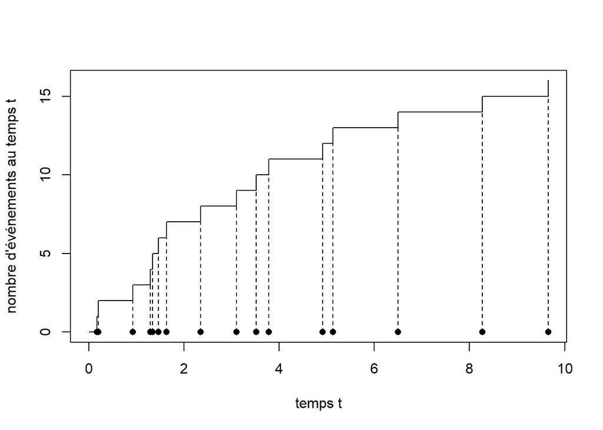

```r
# Simulation d'un processus de Poisson homogène
PPh = simulPPh(2,10)

plot.PP(PPh)
```

### 2.2 Processus de Poisson inhomogènes

On va simuler des processus des Poisson inhomogènes avec plusieurs fonctions d’intensité croissantes.

Simulation d’un processus de Poisson inhomogène avec une fonction d’intensité donnée`lambda_fct` et un majorant `M` sur un intervalle fixé [0,`Tmax`] :

```r
simulPPi = function(lambda_fct,Tmax,M)
{
  PPh = simulPPh(M,Tmax)
  n <- length(PPh)
  list_unif = runif(n, 0, M)

  mask <- list_unif <= sapply(PPh,lambda_fct)
  arrival_times <- PPh[mask]
  arrival_times <- sort(arrival_times)
  return(arrival_times)
}
```

Application à $\lambda_1: x \mapsto 2x.$

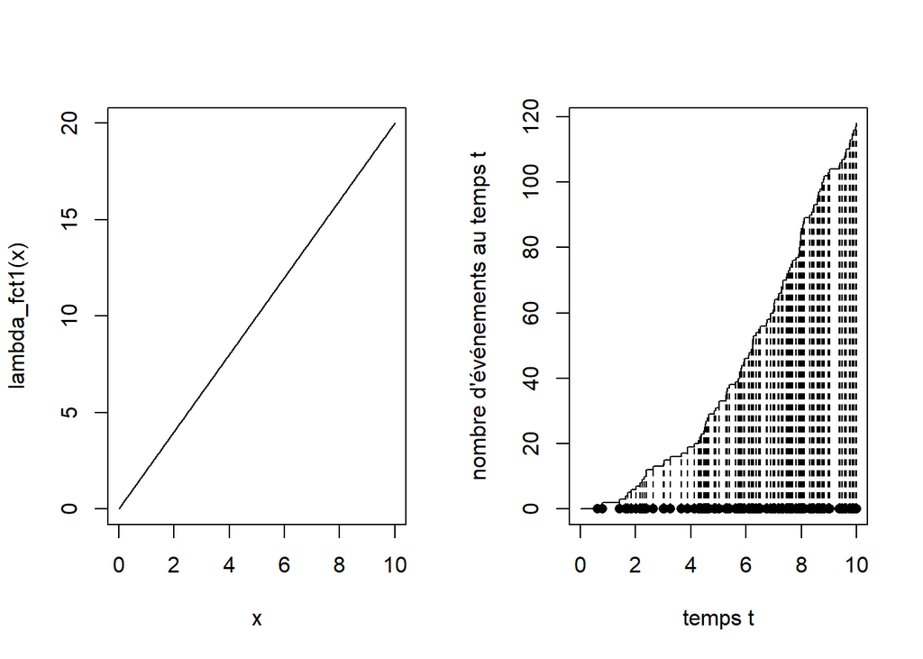

```r
Tmax=10
lambda_fct1 <- function(x){return(2*x)}
M1=20
PPi1 = simulPPi(lambda_fct1, Tmax, M1)

par(mfrow=c(1,2))
curve(lambda_fct1,from=0,to=Tmax,n=1000)
plot.PP(PPi1)
```

Application à $\lambda_2: x \mapsto \frac{3}{10}x^2.$

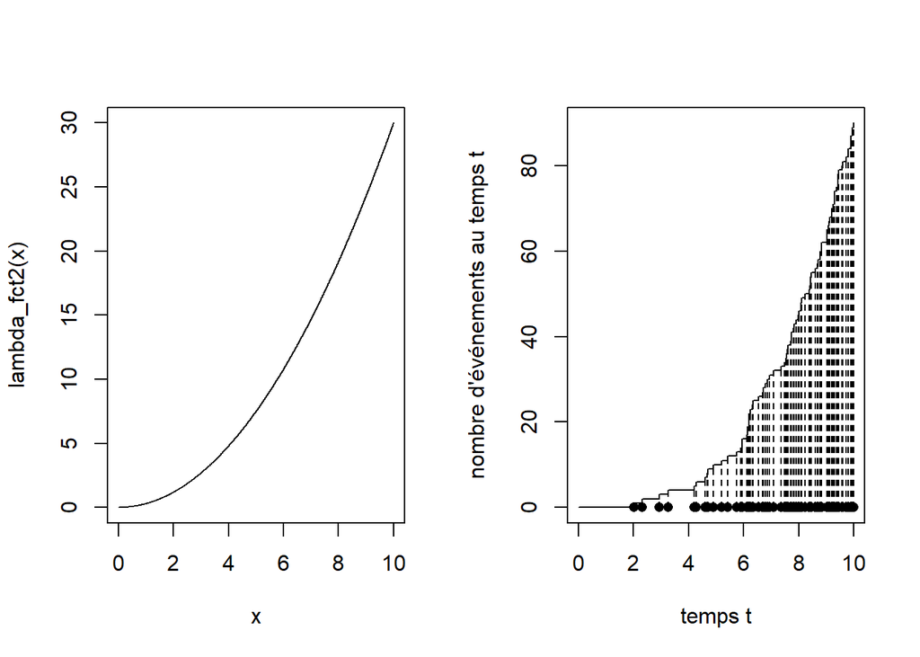

```r
Tmax=10
lambda_fct2 <- function(x){return(0.3*x*x)}
M2=30
PPi2 = simulPPi(lambda_fct2, Tmax, M2)

par(mfrow=c(1,2))
curve(lambda_fct2,from=0,to=Tmax,n=1000)
plot.PP(PPi2)
```

Application à $\lambda_3: x \mapsto 10\times 1_{[0,7]}(x) + 15\times 1_{]7,10]}(x).$

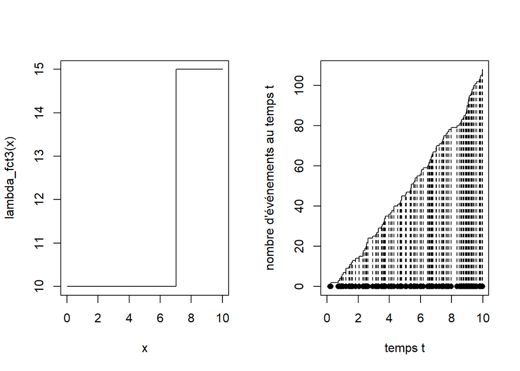

```r
Tmax <- 10
lambda_fct3 <- function(x) { return(10 * ifelse(x >= 0 & x <= 7, 1, 0) + 15 * ifelse(x > 7 & x <= 10, 1, 0)) }
M3 <- 15
PPi3 <- simulPPi(lambda_fct3, Tmax, M3)

par(mfrow=c(1,2))
curve(lambda_fct3, from = 0, to = Tmax, n = 1000)
plot.PP(PPi3)
```

### 2.3 Implémentation des tests

La fonction `test_L` renvoie la $p$-valeur du test $L$ étant données les observation du processus de Poisson (d’intensité croissante) `PP` sur [0,`Tmax`].

```r
test_L <- function(PP,Tmax)
{
  L <- sum(PP) / Tmax
  n = length(PP)
  Zn <- sqrt(12 * n) * (L/n - 1/2)
  p_value = 1 - pnorm(Zn)
  return(p_value)
}
```

Vérifions la loi asymptotique sous $\mathcal{H}_0$ de la statistique de test $Z_n$ ainsi construite.

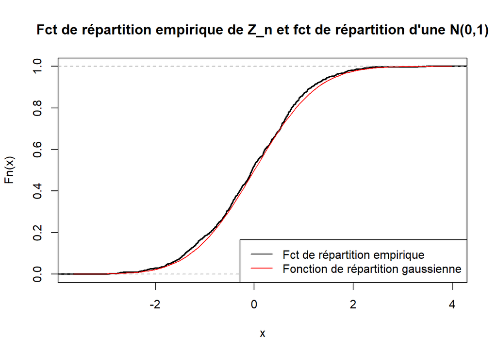

```r
lambda <- 1
Tmax <- 10
num_simulations <- 1000
Zn_values <- numeric(num_simulations)
n <- rpois(1, lambda * Tmax)
for (i in 1:num_simulations) {

  T <- sort(runif(n, 0, Tmax))
  L <- sum(T) / Tmax
  Zn_values[i] <- sqrt(12 * n) * (L/n - 1/2)
}

# On trace la fonction de répartition empirique de Zn
plot(ecdf(Zn_values), main="Fct de répartition empirique de Z_n et fct de répartition d'une N(0,1)",lwd = 2)

# On ajoute de lafonction de répartition théorique d'une distribution normale
curve(pnorm(x), add = TRUE, col = "red")

legend("bottomright", legend=c("Fct de répartition empirique", "Fonction de répartition gaussienne"), col=c("black", "red"), lty=1)
```

La loi asymptotique sous $\mathcal{H}_0$ de $Z_n$ est bien vérifiée. Notons que $Z_n$ converge très vite, en effet ici $n$ est aux alentours de 10 et on a déjà une loi très proche d’une N(0,1).

La fonction `test_Z` renvoie la $p$-valeur du test $Z$ étant données les observation du processus de Poisson (d’intensité croissante) `PP` sur [0,`Tmax`].

```r
test_Z <- function(PP,Tmax)
{
  Z <- 2 * sum(log(Tmax / PP))
  n = length(PP)
  p_value = pchisq(Z, df=2*n)
  return(p_value)
}
```

Vérifions la loi sous $\mathcal{H}_0$ de la statistique de test $Z$ ainsi construite.

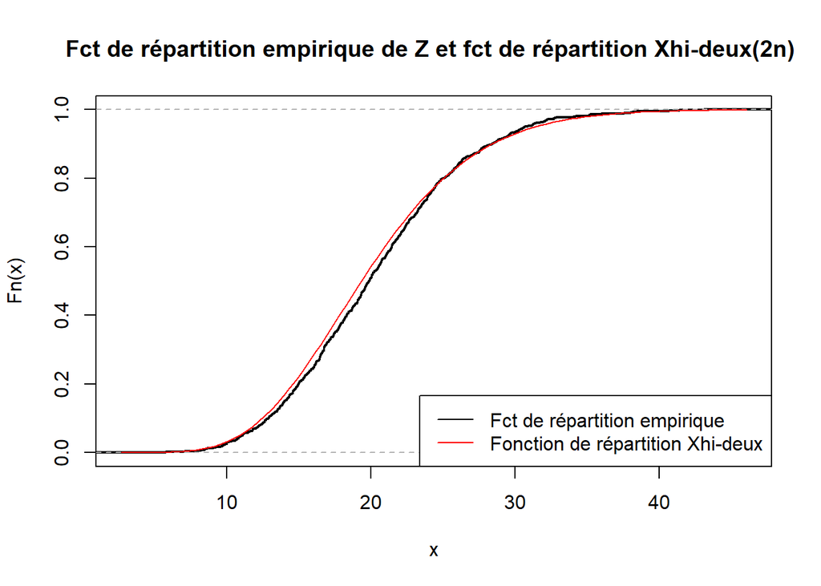

```r
lambda <- 1
Tmax <- 10
num_simulations <- 1000
Z_values <- numeric(num_simulations)
n <- rpois(1, lambda * Tmax)
for (i in 1:num_simulations) {

  T <- sort(runif(n, 0, Tmax))
  Z_values[i] <- 2 * sum(log(Tmax / T))
}

# Fonction de répartition théorique de la distribution Chi-squared
theoretical_df <- 2 * n
theoretical_cdf <- function(x) { pchisq(x, df = theoretical_df) }



# On trace de la fonction de répartition empirique
plot(ecdf(Z_values), main="Fct de répartition empirique de Z et fct de répartition Xhi-deux(2n) ", lwd=2)

# On ajoute de la fonction de répartition théorique
curve(theoretical_cdf(x), add = TRUE, col = "red")

legend("bottomright", legend=c("Fct de répartition empirique", "Fonction de répartition Xhi-deux"), col=c("black", "red"), lty=1)
```

La loi sous $\mathcal{H}_0$ de $Z$ est bien vérifiée.

### 2.4 Niveau et puissance des tests

A présent, vérifions le niveau des tests et comparons leurs puissances sur différents types de fonctions d’intensité croissantes.

#### 2.4.1 Fonctions affines

Simulation par Monte-Carlo du niveau et de la puissance des tests $L$ et $Z$ avec les fonctions d’intensité $x \mapsto \beta x + 1, \quad \beta \geq 0$.

```r
plot.level.power1 <- function(Tmax, TrueBeta, alpha, nsimu,test,nom_du_test)
{
  plot(range(TrueBeta), c(alpha, alpha), ylim=c(0,1), xlab="True beta", ylab="Level/Power",
       type="l", col="red", main=paste(nom_du_test, sep=""))
  abline(1,0,lty=2,col="blue")

  for(beta in TrueBeta)
  {
    lambda_b = function(x){return(x*beta + 1)}
    propReject = 0
    for(sim in 1:nsimu){
      PPi = simulPPi(lambda_b,Tmax,lambda_b(Tmax))
      propReject = propReject + (test(PPi,Tmax) <= alpha)/nsimu
    }

    points(beta, propReject)
    points(beta, propReject + sqrt(abs(propReject*(1-propReject))/nsimu)*qnorm(0.975), pch=2)
    points(beta, propReject - sqrt(abs(propReject*(1-propReject))/nsimu)*qnorm(0.975), pch=6)
  }
}
```

```r
# Test L and Test Z
plot.level.combined <- function(Tmax, TrueBeta, alpha, nsimu, test_L, test_Z, title){
  plot(range(TrueBeta), c(alpha, alpha), ylim=c(0,1), xlab="True beta", ylab="Level/Power",
       type="l", col="red", main=title)
  abline(1,0,lty=2,col="blue")

  for(beta in TrueBeta)
  {
    lambda_b = function(x){return(x*beta + 1)}
    propReject_L = 0
    propReject_Z = 0
    for(sim in 1:nsimu){
      PPi = simulPPi(lambda_b, Tmax, lambda_b(Tmax))
      propReject_L = propReject_L + (test_L(PPi, Tmax) <= alpha) / nsimu
      propReject_Z = propReject_Z + (test_Z(PPi, Tmax) <= alpha) / nsimu
    }
    points(beta, propReject_L, col="blue")
    points(beta, propReject_Z, col="green")
  }
  legend("bottomright", legend=c("Test L", "Test Z"), col=c("blue", "green"), pch=1)
}
```

```r
# Test L and Test Z
plot.level.combined_difference <- function(Tmax, TrueBeta, alpha, nsimu, test_L, test_Z, title){
  plot(range(TrueBeta), c(-0.05, 0.05), ylim=c(-0.02, 0.04), xlab="True beta", ylab="Difference in Level/Power (L - Z)",
       type="n", main=title)
  abline(h=0,lty=2,col="blue")

  for(beta in TrueBeta)
  {
    lambda_b = function(x){return(x*beta + 1)}
    diff_rejection_prop = 0
    for(sim in 1:nsimu){
      PPi = simulPPi(lambda_b, Tmax, lambda_b(Tmax))
      propReject_L = (test_L(PPi, Tmax) <= alpha)
      propReject_Z = (test_Z(PPi, Tmax) <= alpha)
      diff_rejection_prop = diff_rejection_prop + (propReject_L - propReject_Z) / nsimu
    }
    points(beta, diff_rejection_prop, col="blue")
  }
  legend("bottomright", legend="L - Z", col="blue", pch=1)
}
```

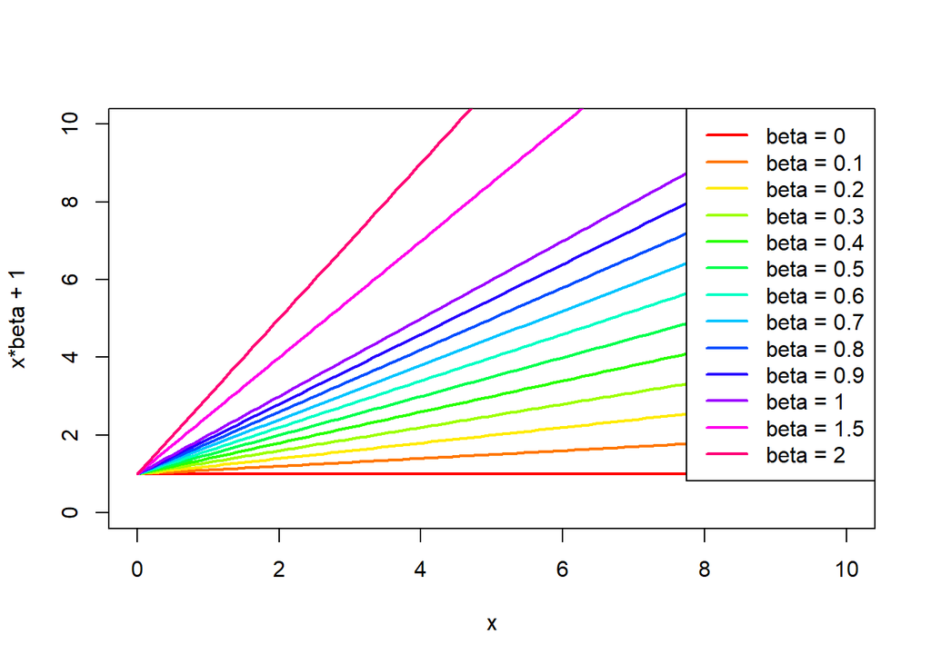

```r
Tmax = 10
alpha=0.05
nsimu=1000
TrueBeta=c(0,0.1,0.2,0.3,0.4,0.5,0.6,0.7,0.8,0.9,1,1.5,2)

# On crée un vecteur de valeurs x
x <- seq(0, Tmax, length.out = 100)

plot(x, rep(NA, length(x)), type="n", ylim=c(0, 10), xlim=c(0, 10), xlab="x", ylab="x*beta + 1")

for (beta in TrueBeta) {
  y <- x*beta + 1
  lines(x, y, col=rainbow(length(TrueBeta))[which(beta == TrueBeta)], lwd=2)
}

legend("topright", legend=paste("beta =", TrueBeta), col=rainbow(length(TrueBeta)), lwd=2)
```

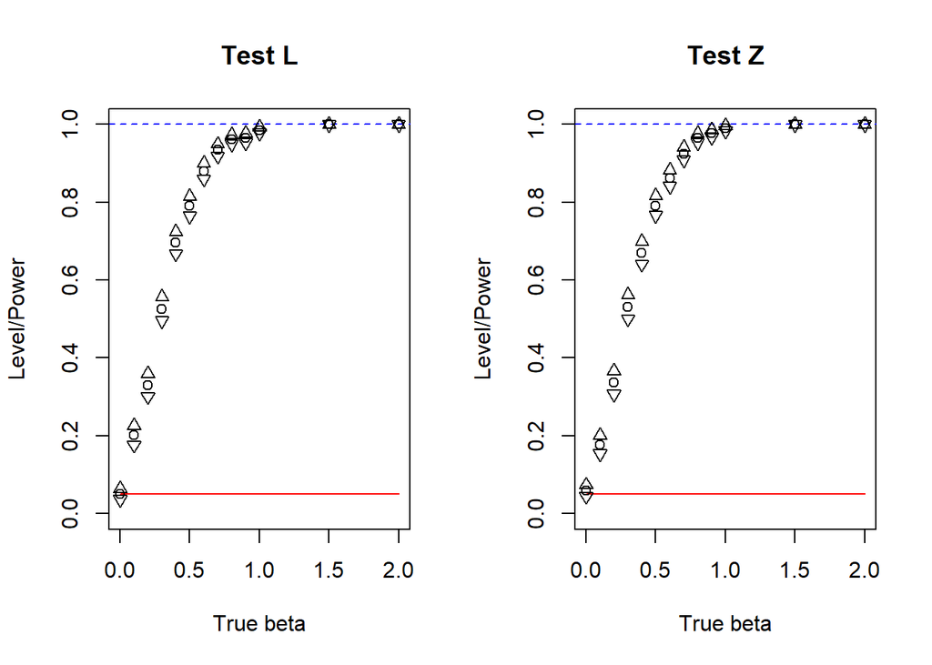

```r
par(mfrow=c(1,2))
plot.level.power1(Tmax,TrueBeta,alpha,nsimu,test_L,"Test L")
plot.level.power1(Tmax,TrueBeta,alpha,nsimu,test_Z,"Test Z")
```

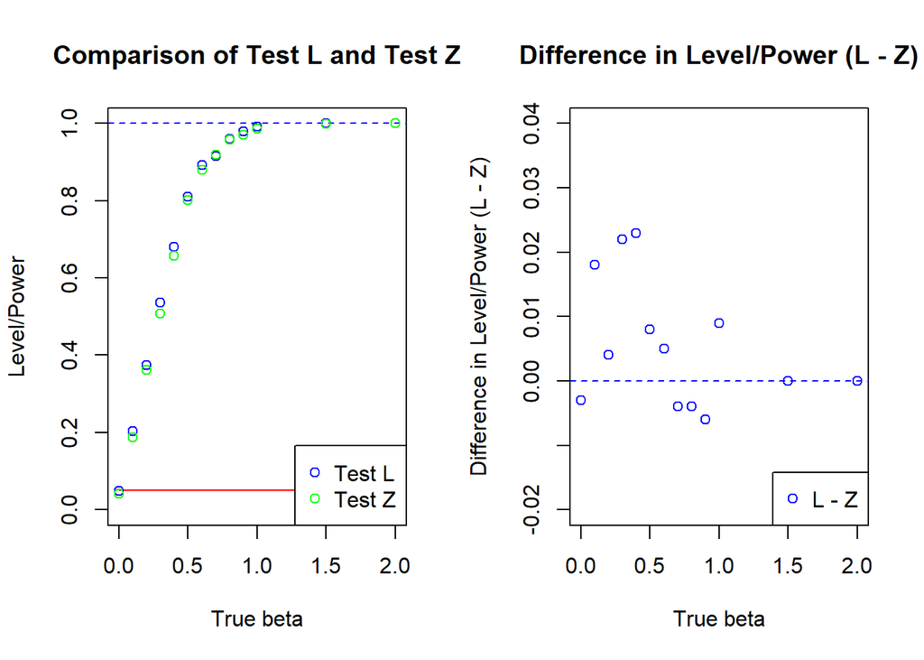

```r
plot.level.combined(Tmax, TrueBeta, alpha, nsimu, test_L, test_Z, "Comparison of Test L and Test Z")

plot.level.combined_difference(Tmax, TrueBeta, alpha, nsimu, test_L, test_Z, "Difference in Level/Power (L - Z)")
```

Les tests sont bien de niveau $\alpha$ (lorsque beta = 0, on est bien dans le cas d’une intensité constante). Pour ce type de fonction, les deux tests semblent de puissance équivalente.

#### 2.4.2 Fonctions puissance

Simulation par Monte-Carlo du niveau et de la puissance des tests $L$ et $Z$ avec les fonctions d’intensité $x \mapsto x^{\beta}, \quad \beta \geq 0$.

```r
plot.level.power2 <- function(Tmax, TrueBeta, alpha, nsimu,test,nom_du_test)
{
  plot(range(TrueBeta), c(alpha, alpha), ylim=c(0,1), xlab="True beta", ylab="Level/Power",
       type="l", col="red", main=paste(nom_du_test, sep=""))
  abline(1,0,lty=2,col="blue")

  for(beta in TrueBeta)
  {
    lambda_b = function(x){return(x**beta)}
    propReject = 0
    for(sim in 1:nsimu){
      PPi = simulPPi(lambda_b,Tmax,lambda_b(Tmax))
      propReject = propReject + (test(PPi,Tmax) <= alpha)/nsimu
    }

    points(beta, propReject)
    points(beta, propReject + sqrt(abs(propReject*(1-propReject))/nsimu)*qnorm(0.975), pch=2)
    points(beta, propReject - sqrt(abs(propReject*(1-propReject))/nsimu)*qnorm(0.975), pch=6)
  }
}
```

```r
plot.level.combined2 <- function(Tmax, TrueBeta, alpha, nsimu, test_L, test_Z, title){
  plot(range(TrueBeta), c(alpha, alpha), ylim=c(0,1), xlab="True beta", ylab="Level/Power",
       type="l", col="red", main=title)
  abline(1,0,lty=2,col="blue")

  for(beta in TrueBeta)
  {
    lambda_b = function(x){return(x**beta)}
    propReject_L = 0
    propReject_Z = 0
    for(sim in 1:nsimu){
      PPi = simulPPi(lambda_b, Tmax, lambda_b(Tmax))
      propReject_L = propReject_L + (test_L(PPi, Tmax) <= alpha) / nsimu
      propReject_Z = propReject_Z + (test_Z(PPi, Tmax) <= alpha) / nsimu
    }
    points(beta, propReject_L, col="blue")
    points(beta, propReject_Z, col="green")
  }
  legend("bottomright", legend=c("Test L", "Test Z"), col=c("blue", "green"), pch=1)
}
```

```r
plot.level.combined_difference2 <- function(Tmax, TrueBeta, alpha, nsimu, test_L, test_Z, title){
  plot(range(TrueBeta), c(-0.05, 0.05), ylim=c(-0.02, 0.08), xlab="True beta", ylab="Difference in Level/Power (Z - L)",
       type="n", main=title)
  abline(h=0,lty=2,col="blue")

  for(beta in TrueBeta)
  {
    lambda_b = function(x){return(x**beta)}
    diff_rejection_prop = 0
    for(sim in 1:nsimu){
      PPi = simulPPi(lambda_b, Tmax, lambda_b(Tmax))
      propReject_L = (test_L(PPi, Tmax) <= alpha)
      propReject_Z = (test_Z(PPi, Tmax) <= alpha)
      diff_rejection_prop = diff_rejection_prop + (propReject_Z - propReject_L) / nsimu
    }
    points(beta, diff_rejection_prop, col="blue")
  }
  legend("bottomright", legend="Z - L", col="blue", pch=1)
}
```

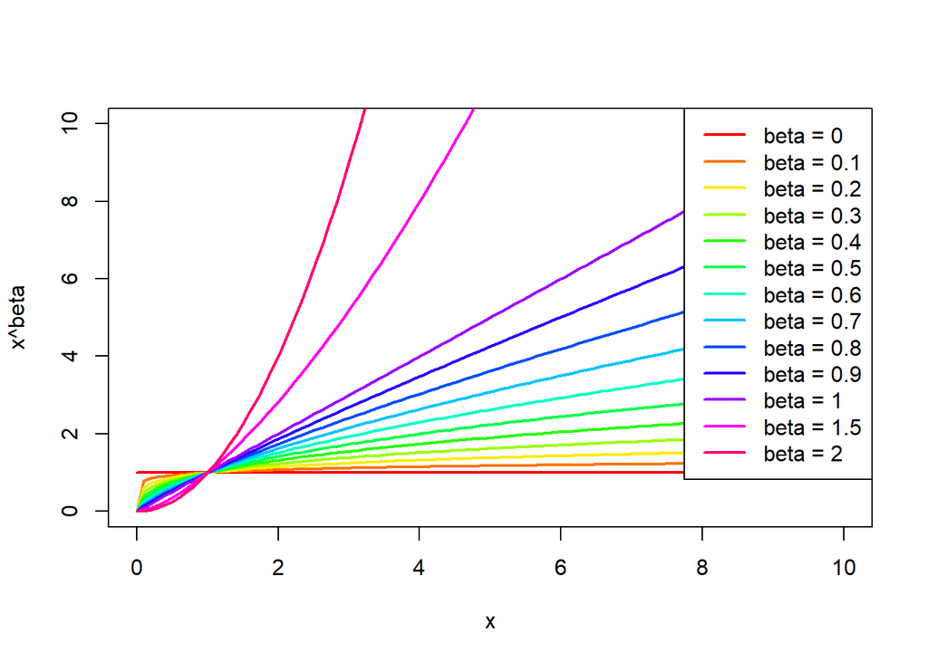

```r
Tmax = 10
alpha=0.05
nsimu=1000
TrueBeta=c(0,0.1,0.2,0.3,0.4,0.5,0.6,0.7,0.8,0.9,1,1.5,2)

x <- seq(0, Tmax, length.out = 100)

plot(x, rep(NA, length(x)), type="n", ylim=c(0, 10), xlim=c(0, 10), xlab="x", ylab="x^beta")

for (beta in TrueBeta) {
  y <- x**beta
  lines(x, y, col=rainbow(length(TrueBeta))[which(beta == TrueBeta)], lwd=2)
}

legend("topright", legend=paste("beta =", TrueBeta), col=rainbow(length(TrueBeta)), lwd=2)
```

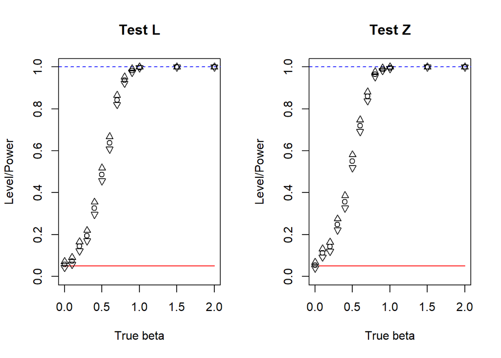

```r
par(mfrow=c(1,2))
plot.level.power2(Tmax,TrueBeta,alpha,nsimu,test_L,"Test L")
plot.level.power2(Tmax,TrueBeta,alpha,nsimu,test_Z,"Test Z")
```

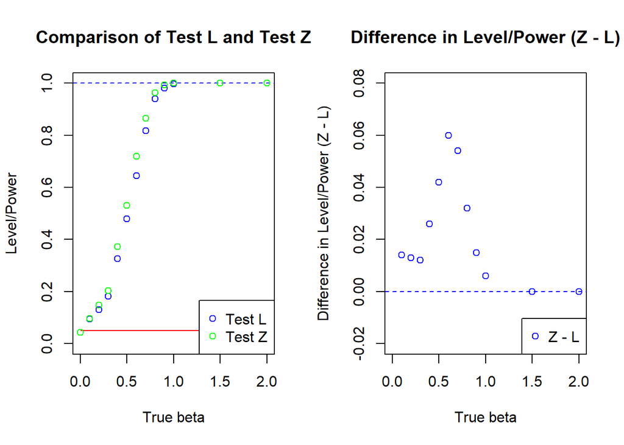

```r
plot.level.combined2(Tmax, TrueBeta, alpha, nsimu, test_L, test_Z, "Comparison of Test L and Test Z")

plot.level.combined_difference2(Tmax, TrueBeta, alpha, nsimu, test_L, test_Z, "Difference in Level/Power (Z - L)")
```

Les test sont bien de niveau $\alpha$ (lorsque beta = 0, on est bien dans le cas d’une intensité constante). Ici, le test $Z$ est légèrement plus puissant que le test $L$.

#### 2.4.3 Fonctions en escalier

Simulation par Monte-Carlo du niveau et de la puissance des tests $L$ et $Z$ avec les fonctions d’intensité $x \mapsto 1_{[0,7]}(x) + k 1_{]7,10]}(x), \quad k \in \mathbb{N}^{*}$.

```r
plot.level.power3 <- function(Tmax, TrueK, alpha, nsimu,test,nom_du_test)
{
  plot(range(TrueK), c(alpha, alpha), ylim=c(0,1), xlab="True k", ylab="Level/Power",
       type="l", col="red", main=paste(nom_du_test, sep=""))
  abline(1,0,lty=2,col="blue")

  for(k in TrueK)
  {
    lambda_k <- function(x) { return(ifelse(x >= 0 & x <= 7, 1, 0) + k * ifelse(x > 7 & x <= 10, 1, 0)) }
    propReject = 0
    for(sim in 1:nsimu){
      PPi = simulPPi(lambda_k,Tmax,lambda_k(Tmax))
      propReject = propReject + (test(PPi,Tmax) <= alpha)/nsimu
    }
    # plot the confidence intervals
    points(k, propReject)
    points(k, propReject + sqrt(abs(propReject*(1-propReject))/nsimu)*qnorm(0.975), pch=2)
    points(k, propReject - sqrt(abs(propReject*(1-propReject))/nsimu)*qnorm(0.975), pch=6)
  }
}
```

```r
# Test L et Test Z
plot.level.combined3 <- function(Tmax, TrueK, alpha, nsimu, test_L, test_Z, title){
  plot(range(TrueK), c(alpha, alpha), ylim=c(0,1), xlab="True k", ylab="Level/Power",
       type="l", col="red", main=title)
  abline(1,0,lty=2,col="blue")

  for(k in TrueK)
  {
    lambda_k <- function(x) { return(ifelse(x >= 0 & x <= 7, 1, 0) + k * ifelse(x > 7 & x <= 10, 1, 0)) }
    propReject_L = 0
    propReject_Z = 0
    for(sim in 1:nsimu){
      PPi = simulPPi(lambda_k, Tmax, lambda_k(Tmax))
      propReject_L = propReject_L + (test_L(PPi, Tmax) <= alpha) / nsimu
      propReject_Z = propReject_Z + (test_Z(PPi, Tmax) <= alpha) / nsimu
    }
    points(k, propReject_L, col="blue")
    points(k, propReject_Z, col="green")
  }
  legend("bottomright", legend=c("Test L", "Test Z"), col=c("blue", "green"), pch=1)
}
```

```r
# Test L et Test Z
plot.level.combined_difference3 <- function(Tmax, TrueK, alpha, nsimu, test_L, test_Z, title){
  plot(range(TrueK), c(-0.05, 0.05), ylim=c(-0.05, 0.18), xlab="True k", ylab="Difference in Level/Power (L - Z)",
       type="n", main=title)
  abline(h=0,lty=2,col="blue")

  for(k in TrueK)
  {
    lambda_k <- function(x) { return(ifelse(x >= 0 & x <= 7, 1, 0) + k * ifelse(x > 7 & x <= 10, 1, 0)) }
    diff_rejection_prop = 0
    for(sim in 1:nsimu){
      PPi = simulPPi(lambda_k, Tmax, lambda_k(Tmax))
      propReject_L = (test_L(PPi, Tmax) <= alpha)
      propReject_Z = (test_Z(PPi, Tmax) <= alpha)
      diff_rejection_prop = diff_rejection_prop + (propReject_L - propReject_Z) / nsimu
    }
    points(k, diff_rejection_prop, col="blue")
  }
  legend("bottomright", legend="L - Z", col="blue", pch=1)
}
```

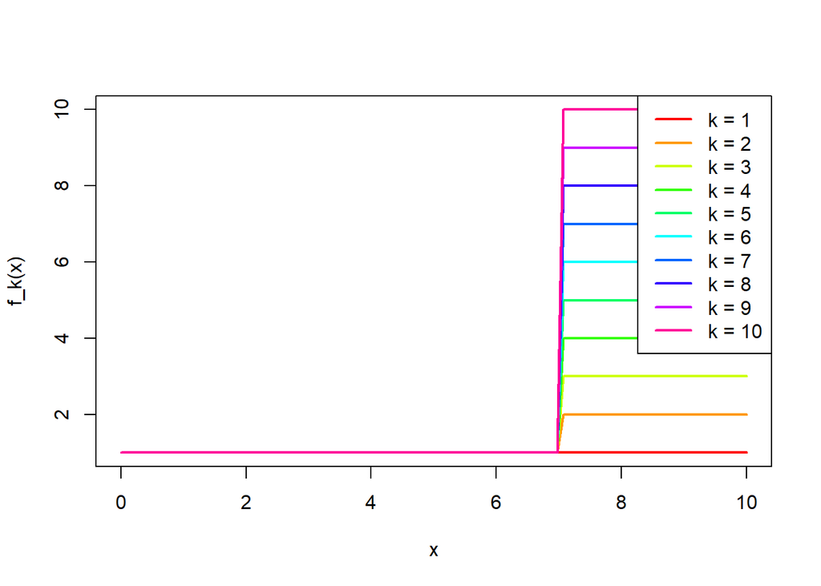

```r
Tmax = 10
alpha=0.05
nsimu=1000
TrueK=c(1,2,3,4,5,6,7,8,9,10)

x <- seq(0, Tmax, length.out = 100)

plot(x, rep(NA, length(x)), type="n", ylim=c(1, 10), xlim=c(0, 10), xlab="x", ylab="f_k(x)" )

for (k in TrueK) {
  y <- ifelse(x >= 0 & x <= 7, 1, 0) + (k) * ifelse(x > 7 & x <= 10, 1, 0)
  lines(x, y, col=rainbow(length(TrueK))[which(k == TrueK)], lwd=2)
}

legend("topright", legend=paste("k =", TrueK), col=rainbow(length(TrueK)), lwd=2)
```

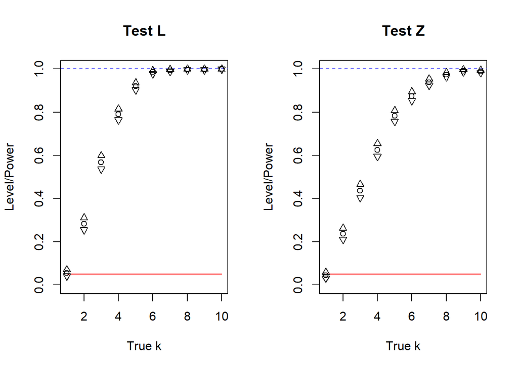

```r
par(mfrow=c(1,2))
plot.level.power3(Tmax,TrueK,alpha,nsimu,test_L,"Test L")
plot.level.power3(Tmax,TrueK,alpha,nsimu,test_Z,"Test Z")
```

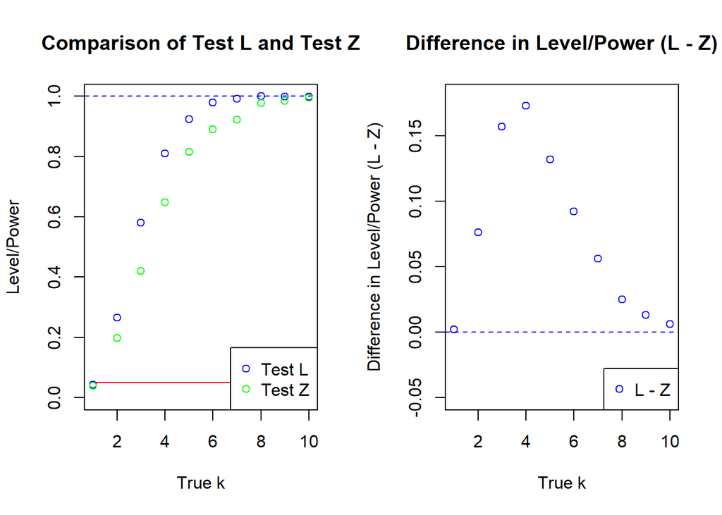

```r
plot.level.combined3(Tmax, TrueK, alpha, nsimu, test_L, test_Z, "Comparison of Test L and Test Z")

plot.level.combined_difference3(Tmax, TrueK, alpha, nsimu, test_L, test_Z, "Difference in Level/Power (L - Z)")
```

Le test bien de niveau $\alpha$ (lorsque k = 1, on est bien dans le cas d’une intensité constante). Cette fois-ci, c’est le test $L$ qui est le plus puissant.

## 3 Test sur données réelles

Maintenant, nous allons appliquer ces tests sur des temps d’arrivée d’incendies au Danemark entre 1980 et 1990.

Importons les données.

```r
#install.packages("evir")
```

```r
library(evir)
data("danish")
length(danish)
```

```
## [1] 2167
```

```r
summary(danish)
```

```
##    Min. 1st Qu.  Median    Mean 3rd Qu.    Max.
##   1.000   1.321   1.778   3.385   2.967 263.250
```

```r
#print(danish)
str(danish)
```

```
##  num [1:2167] 1.68 2.09 1.73 1.78 4.61 ...
##  - attr(*, "times")= POSIXt[1:2167], format: "1980-01-03 01:00:00" "1980-01-04 01:00:00" ...
```

Récupérons les temps d’arrivée de danish :

```r
data <- attributes(danish)$times

data <- as.POSIXct(data, tz = "Europe/Paris") # On convertit les valeurs du vecteur temps_arrivee en objets de classe POSIXct, qui sont des objets de date et d'heure dans R. On se place sur le fuseau horaire de Paris.

#print(data)
```

On remarque que les réclamations se font toujours a la même heure (1h en heure d’hiver et 2h en heure d’été). Nous allons donc regarder les jours d’occurence.

Retirons les doublons dans data.

```r
data <- unique(data)

# On affiche les temps d'arrivée uniques
#print(data)
```

### 3.1 Test d’homogénéité des réclamations de 1980 à 1990

Nous allons donc étudier les occurences de réclamations d’incendies sur les 4018 jours entre le 1er janvier 1980 et le 31 décembre 1990. Construisons `temps_arrivee` en remplaçant chaque date de `data` par un nombre entre 0 et 4017 sachant que 0 correspondant au 1er janvier 1980 et 4017 au 31 décembre 1990 et affichons le processus de Poisson associé.

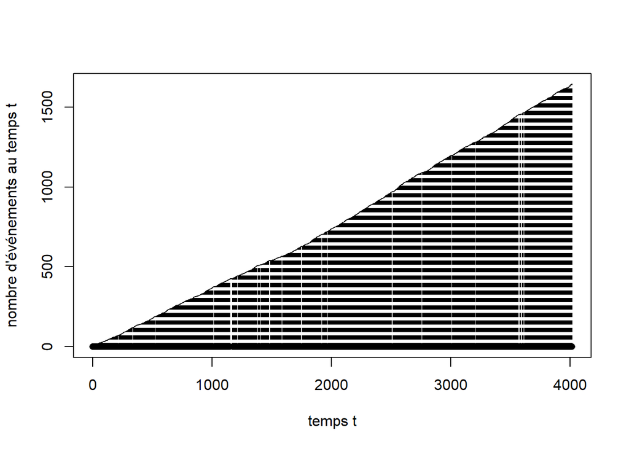

```r
date_debut <- as.Date("1980-01-01")
date_fin <- as.Date("1990-12-31")

# On Calcule la différence en jours entre chaque date et le 1er janvier 1980
temps_arrivee <- as.numeric(difftime(data, date_debut, units = "days"))

# On affiche les nombres correspondant aux dates
#print(temps_arrivee)
plot.PP(temps_arrivee)
```

On remarque une évolution non linéaire du nombre de réclamations en fonction du temps dans la fenêtre de temps 1500 à 2000 environ. Cela suggère une inhomogénéité de temps_arrivee.

Maintenant, effectuons les tests d’homogénéité de Poisson L et Z sur temps_arrivee

```r
print(paste("p-valeur du test L :",test_L(temps_arrivee,4017)))
```

```
## [1] "p-valeur du test L : 0.000119972725516004"
```

```r
print(paste("p-valeur du test Z :",test_Z(temps_arrivee,4017)))
```

```
## [1] "p-valeur du test Z : 0.00068621441121268"
```

Les $p$-valeurs des 2 tests sont très inférieures à 5%. On rejette l’homogénéité de temps_arrivee au niveau 5% avec conviction.

### 3.2 Test année par année : FWER avec correction de Bonferroni

On peut se demander si l’inhomogénéité de temps_arrivee est localisée sur une année en particulier.

Pour $i \in \{1, \ldots, 11\}$, notons $\mathcal{H}_{0,i}$ : “temps_arrivee est homogène sur la $i$-ème année”. Nous allons tester chaque $\mathcal{H}_{0,i}$ en contrôlant la family wise error rate (FWER) ie le risque de rejeter au moins un $\mathcal{H}_{0,i}$ à tort. Pour cela, on effectue la correction de Bonferroni c’est-à-dire on teste chaque $\mathcal{H}_{0,i}$ au niveau $\frac{\alpha}{11}$ de sorte que

$$\begin{align*}
FWER &= \mathbb{P}\left( \text{rejeter au moins un }
\mathcal{H}_{0,i} \text{ à tort} \right) \\
&= \mathbb{P}\left( \bigcup_{i=1}^{11} \{ \text{rejeter }
\mathcal{H}_{0,i} \text{ à tort} \} \right) \\
&\leq \sum_{i=1}^{11} \mathbb{P}\left( \text{rejeter }
\mathcal{H}_{0,i} \text{ à tort} \right) \\
& \leq \sum_{i=1}^{11} \frac{\alpha}{11} = \alpha
\end{align*}$$

Définissons `temps_arrivee1` où temps_arrivee1[i] représente le processus temps_arrivee sur l’année i où l’on a remis à 0 le début de l’année $i$.

```r
library(lubridate)
# On définit les dates de début et de fin
date_debut <- as.Date("1980-01-01")
date_fin <- as.Date("1990-12-31")

nb_annees <- as.numeric(format(date_fin, "%Y")) - as.numeric(format(date_debut, "%Y")) + 1

# On anitialise le vecteur de vecteurs temps_arrivee1
temps_arrivee1 <- vector("list", length = nb_annees)

for (i in 0:(nb_annees - 1)) { # Pour parcourir chaque année
  # Début de l'année
  date_debut_annee <- as.Date(paste0(format(date_debut + years(i)), "-01-01"))


  date_fin_annee <- as.Date(paste0(format(date_debut + years(i)), "-12-31"))

  # On filtre les dates pour l'année i
  dates_annee_i <- data[format(data, "%Y") == format(date_debut + years(i), "%Y")]


  temps_arrivee_annee <- as.numeric(difftime(dates_annee_i, date_fin_annee, units = "days"))


  temps_arrivee1[[i + 1]] <- temps_arrivee_annee
}


print(temps_arrivee1)
```

[output not shown]

[output cut: 101 more lines]

Affichons les processus pour chaque année.

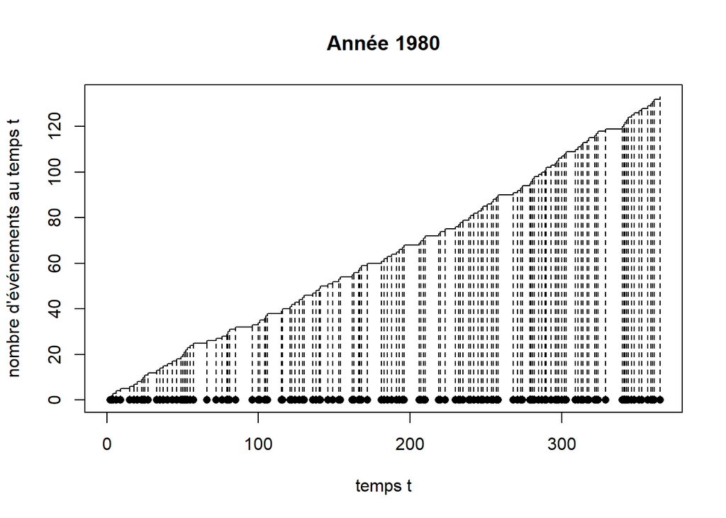

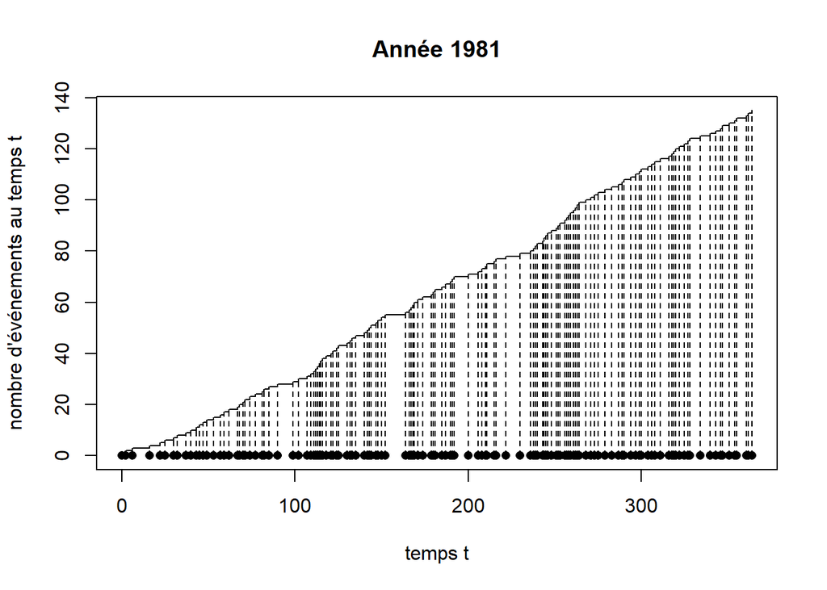

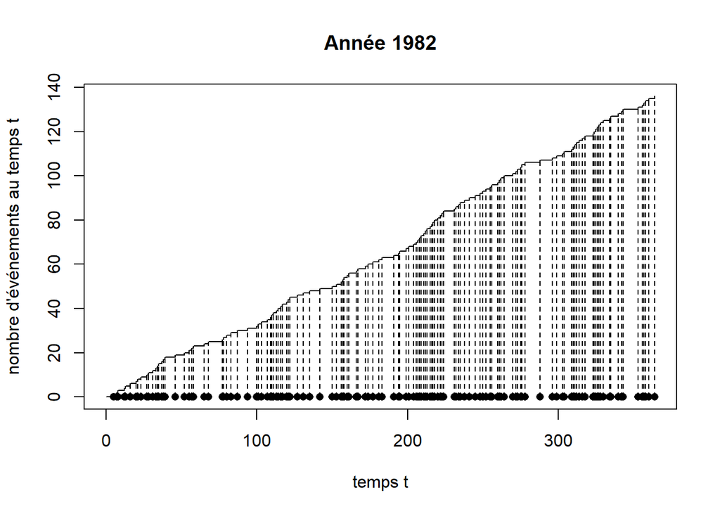

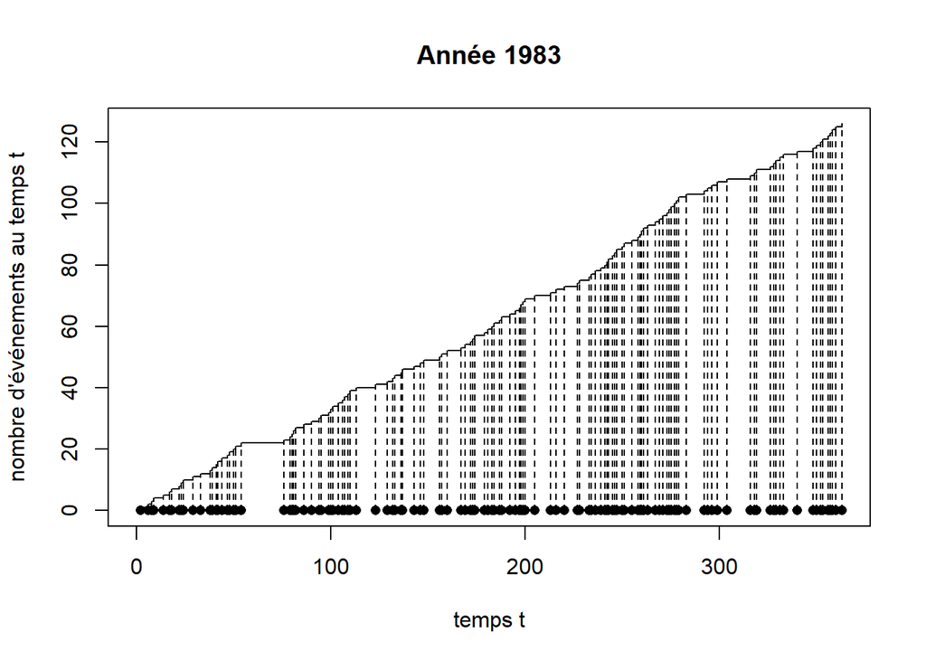

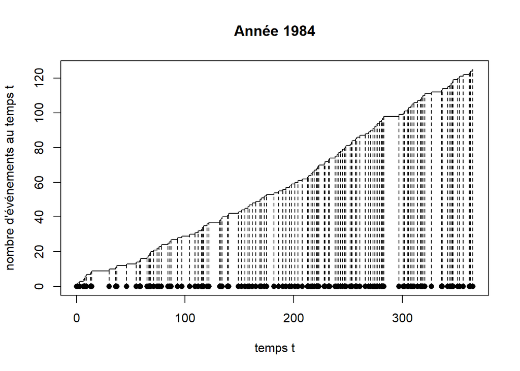

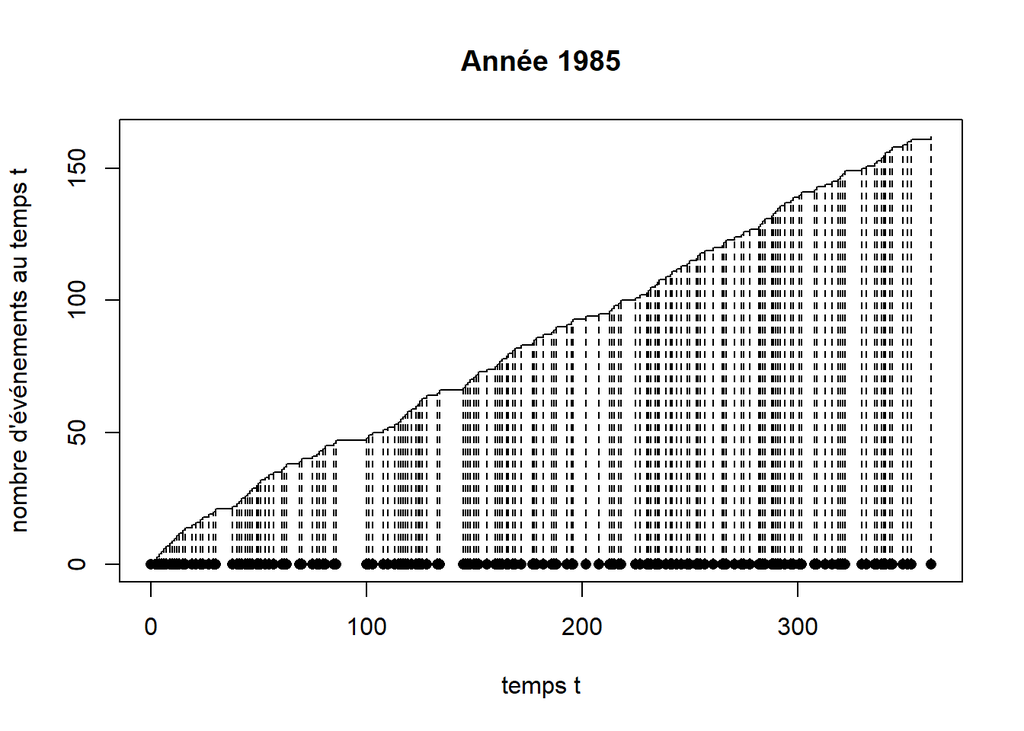

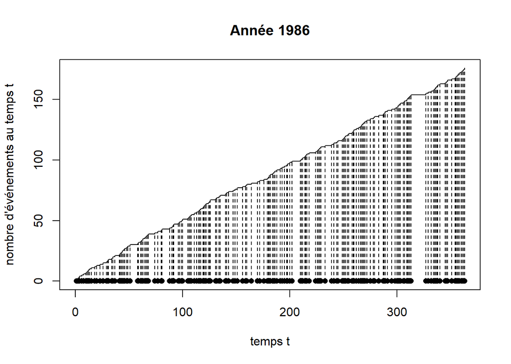

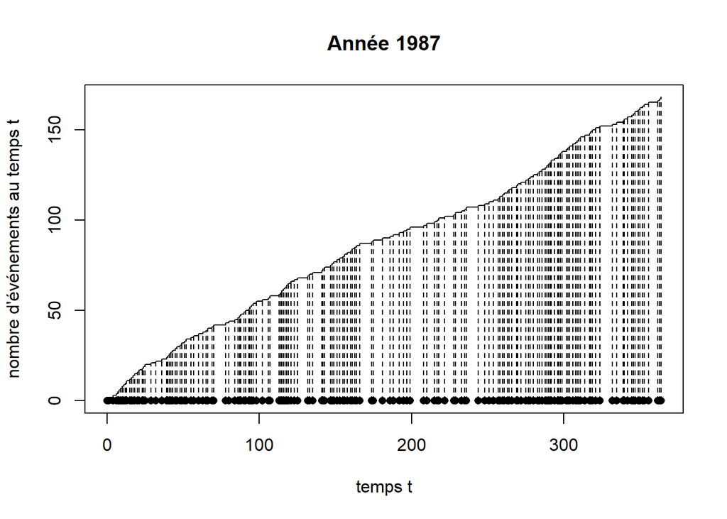

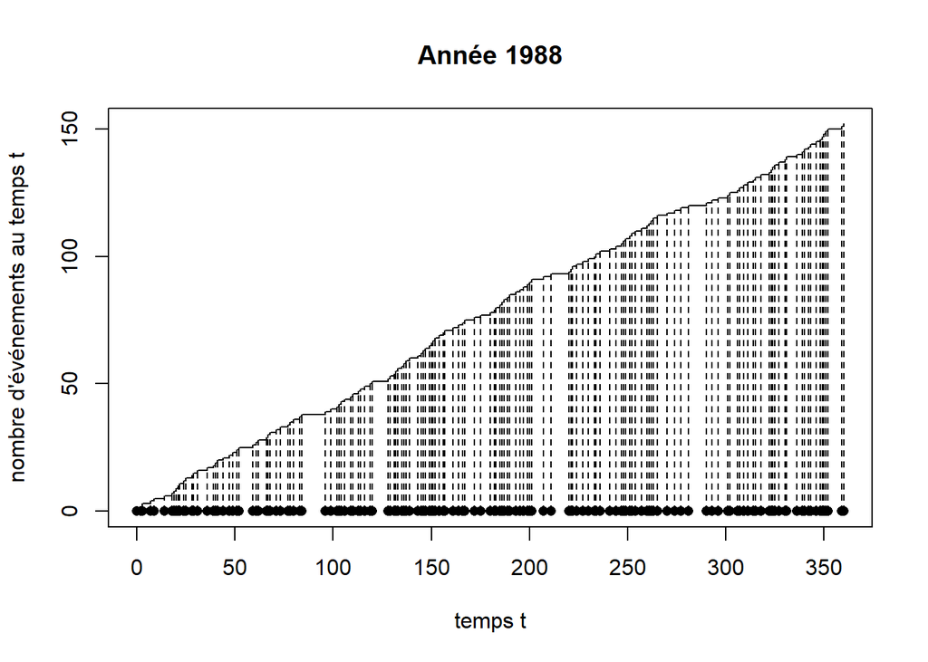

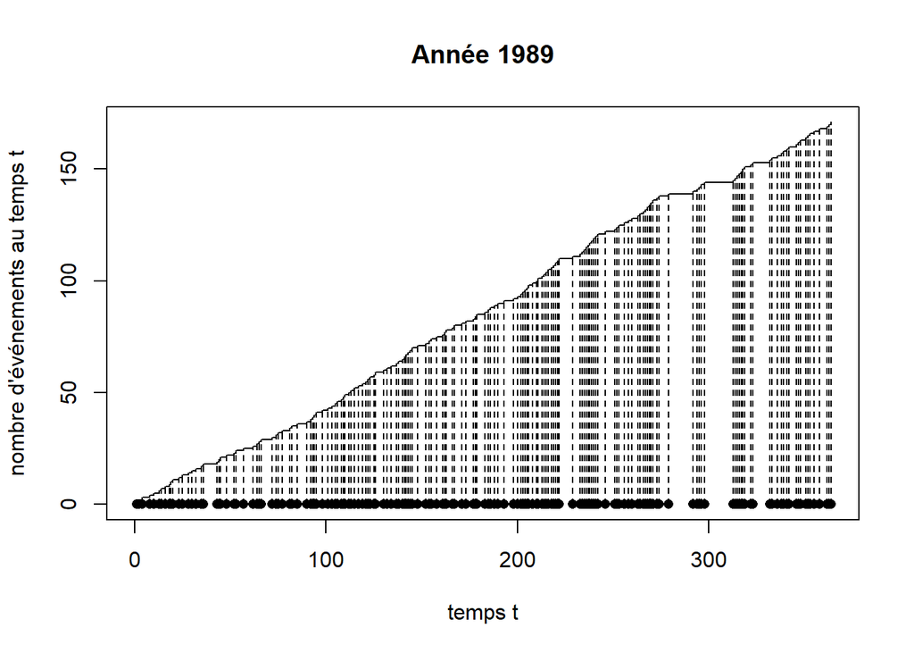

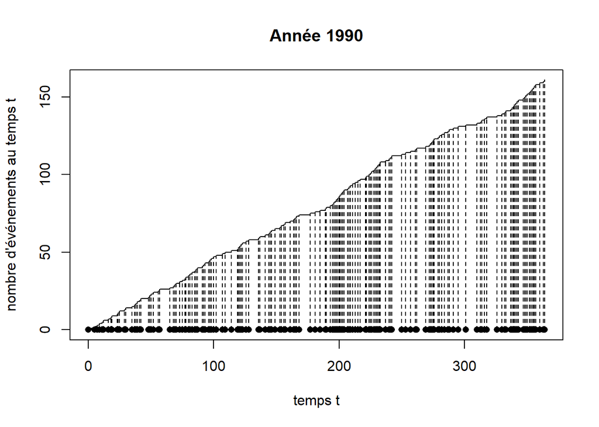

```r
# On visualise les processus sur chaque année
for (i in seq_along(temps_arrivee1)) {
  current_data <- temps_arrivee1[[i]]
  plot.PP(current_data)
  if (dev.cur() != 1) {
    title(paste("Année", 1979 + i))
  } else {
    print(paste("No active plot device for index", i))
  }
}
```

Le nombre de réclamations semble linéaire au cours du temps pour chaque année, ce qui suggère que temps_arrivee est homogène année par année.

Effectuons maintenant les tests de chaque $\mathcal{H}_{0,i}$ au niveau $\frac{\alpha}{11}$.

```r
alpha = 0.05

test = test_L

for (i in seq_along(temps_arrivee1)) {
  if (i %% 4 == 1) {
    p = test(temps_arrivee1[[i]], 365)
  } else {
    p = test(temps_arrivee1[[i]], 364)
  }

  if (p < alpha/11) {
    print(paste("temps_arrivee non homogène pour l'année" ,1979 + i,"avec p-valeur =", p))
  } else {
    print(paste("temps_arrivee homogène pour l'année" ,1979 + i,"avec p-valeur =", p))
  }
}
```

```
## [1] "temps_arrivee homogène pour l'année 1980 avec p-valeur = 0.204217621572501"
## [1] "temps_arrivee homogène pour l'année 1981 avec p-valeur = 0.165465811363533"
## [1] "temps_arrivee homogène pour l'année 1982 avec p-valeur = 0.25509016609731"
## [1] "temps_arrivee homogène pour l'année 1983 avec p-valeur = 0.361841376632127"
## [1] "temps_arrivee homogène pour l'année 1984 avec p-valeur = 0.0932055230758404"
## [1] "temps_arrivee homogène pour l'année 1985 avec p-valeur = 0.883045636019174"
## [1] "temps_arrivee homogène pour l'année 1986 avec p-valeur = 0.570318926833199"
## [1] "temps_arrivee homogène pour l'année 1987 avec p-valeur = 0.788660962914682"
## [1] "temps_arrivee homogène pour l'année 1988 avec p-valeur = 0.685332282339073"
## [1] "temps_arrivee homogène pour l'année 1989 avec p-valeur = 0.526111590154055"
## [1] "temps_arrivee homogène pour l'année 1990 avec p-valeur = 0.3858086494751"
```

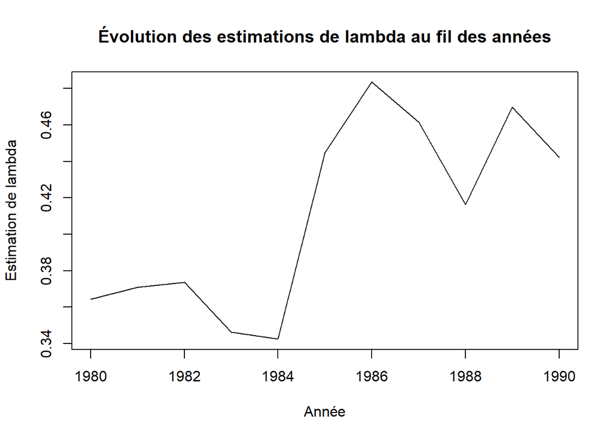

```r
estimations_lambda <- numeric(length(temps_arrivee1))
annees <- numeric(length(temps_arrivee1))

for (i in seq_along(temps_arrivee1)) { # Boucle sur chaque année
  if (i %% 4 == 1) { # Estimation de lambda pour l'année i
    lambda_estimate <- length(temps_arrivee1[[i]]) / 365
  } else {
    lambda_estimate <- length(temps_arrivee1[[i]]) / 364
  }

  # On stocke l'estimation de lambda pour l'année i
  estimations_lambda[i] <- lambda_estimate
  annees[i] <- 1979 + i

   # print(paste("Estimation de lambda pour l'année", 1979 + i, ":", lambda_estimate))
}

# On trace l'évolution des estimations de lambda
plot(annees, estimations_lambda, type = "l", xlab = "Année", ylab = "Estimation de lambda",
     main = "Évolution des estimations de lambda au fil des années")
```

On remarque bien une évolution de l’intensité estimée sur chaque année, notamment une forte augmentation entre 1984 et 1986 ce qui explique l’inhomogénéité de temps_arrivee sur les 11 ans.

## Conclusion

Nous avons construit les tests $L$ (de Laplace) et $Z$ pour savoir si un processus de Poisson $(N_t)_{t \in \mathbb{R}^{+}}$ de fonction d’intensité $\lambda(\cdot)$ croissante est homogène ou non. Nous avons appliqué ces tests pour des fonctions affines, puissances et constantes par morceaux afin de les comparer en mesurant leur puissance.

Pour les fonctions affines, les deux test $L$ et $Z$ sont de puissance équivalente.

Pour les fonctions puissance, le test $L$ est plus puissant que le test $Z$.

Pour les fonctions constantes par morceaux, le test $Z$ est légèrement plus puissant que le test $L$.

Nous avons ensuite appliqué ces tests sur des temps d’arrivée d’incendies au Danemark. Lorsque nous appliquons les tests $L$ et $Z$ pour la période entre 1980 et 1990, nous obtenons des p-valeurs très inférieures à 5%, ce qui nous permet de rejeter avec convitcion l’homogénéité des temps d’arrivée.

Lorsque les années sont étudiées individuellement, la linéarité des réclamations d’incendies suggère que les temps d’arrivées sont homogènes. Néanmoins, on note une évolution de l’intensité estimée sur chaque année, notamment une forte augmentation entre 1984 et 1986 ce qui explique l’inhomogénéité des temps d’arrivée sur les onze années.

Il pourrait être intéressant par la suite de déterminer la fonction d’intensité du processus des réclamations, qui serait probablement sous la forme d’une fonction constante par morceaux étant donné l’homogénéité du processus sur chaque année.

D’autres tests basés sur le rapport de vraisemblance de de Boswell, ou sur les paramètres $\tau$ de Kendall et $\rho$ de Spearman peuvent être considérés pour étudier des processus d’intensité $\lambda(\cdot)$ croissante.

## Références

Bain, L. J., Engelhardt, M., & Wright, F. T. (1985). Tests for an Increasing Trend in the Intensity of a Poisson Process: A Power Study. Journal of the American Statistical Association, 80(390), 419–422. https://doi.org/10.2307/2287907

Lilliefors, H. W. (1969). On the Kolmogorov-Smirnov Test for the Exponential Distribution with Mean Unknown. Journal of the American Statistical Association, 64(325), 387–389. https://doi.org/10.2307/2283748

Benjamini, Y., & Hochberg, Y. (1995). Controlling the False Discovery Rate: A Practical and Powerful Approach to Multiple Testing. Journal of the Royal Statistical Society. Series B (Methodological), 57(1), 289–300. http://www.jstor.org/stable/2346101